# Machine Learning with Coursera

Jae Kwan Koo

# Clustering

## Unsupervised learning introduction

### 비지도 학습이란?

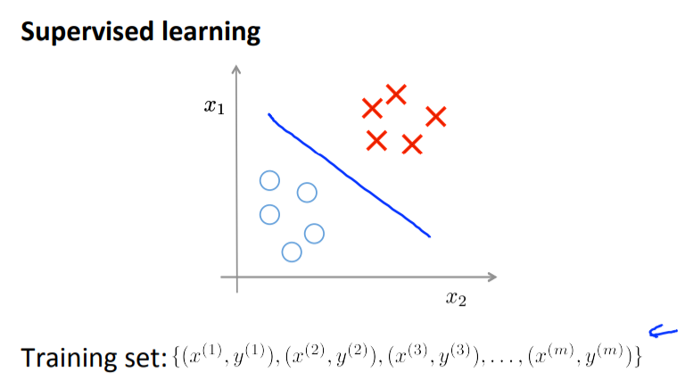

지도 학습 데이터가 주어졌을 때(label이 존재), 목표는 두 그룹의 경계선을 찾는 것이다. 이 경우, 데이터를 가설에 맞추어 fitting한다.

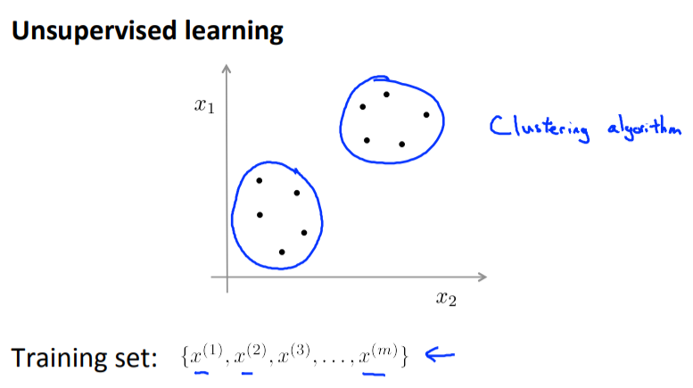

반대로, 비지도 학습에서는 label이 없다.  
비지도 학습에서 label이 없는 훈련 집합에 algorithm을 적용하여 어떤 구조를 찾도록 하는 것이다.

여기서는 data는 algorithm에 의해 두 개의 cluster로 구성되어있고, 이는 clustering algorithm이다.

1. 시장을 세분화해 마케팅 전략을 세울 때, 고객의 데이터베이스를 가지고 고객을 서로 다른 몇 개의 그룹으로 분류  
   각각의 그룹에게 다른 물품을 판매하거나 다른 서비스 가능
2. 소셜 네트워크 분석을 통해 사람들의 소셜 네트워크를 조사  
   페이스북이나 Google+ 같은 SNS, 혹은 사람들이 이메일을 자주 주고받는 대상에 관한 정보를 보고 그룹 속에서 일관성을 찾는다  
   네트워크 안에서 어떤 사람들이 같은 그룹에 있는지 찾는다.

## K-means algorithm

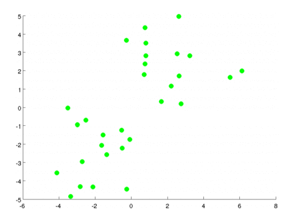

K-means 원리

데이터를 2개의 클러스터로 나누려고 한다.

1. 초기에 cluster centroid라고 불리는 2개의 점을 무작위로 찍는다
2. 각 cluster centroid에 더 가까운 데이터들을 그 점의 색으로 할당한다.
3. 각각 같은 색의 cluster의 중심으로 cluster centroid를 옮긴다.
4. 2~3을 반복하다가 더이상 변화가 없으면 수렴했다고 판단한다.

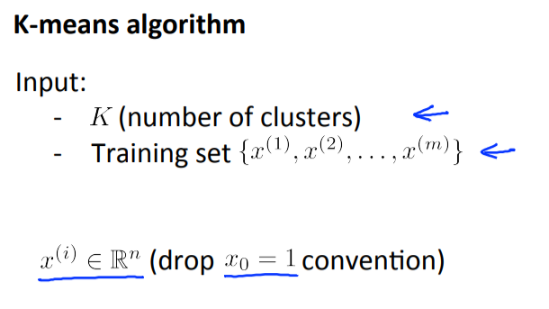

K means algorithm은 2가지 input을 가진다.

- K : 데이터에서 찾기를 원하는 클러스터의 수
  - 나중에 k를 선택하는 방법에 대해 생각하자
- unlabeled training set
  - we don’t have the labels Y anymore

비지도 학습에서는 $x_0=1$을 고려하지 않고 삭제한다. (n+1 dimensions이 아닌 n demiensions)

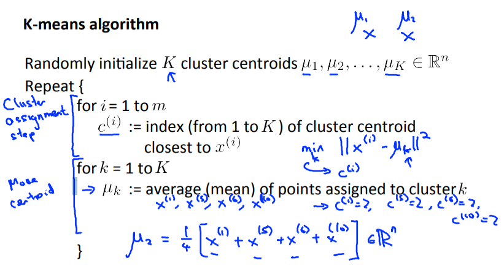

1. 무작위로 K개의 cluster centroids $\mu_1$,…,$\mu_K$를 정한다.
2. training set의 갯수 m만큼 반복한다. 반복의 내용은 아래와 같다.  
   $c^{(i)}$ : $x^{(i)}$에 가까운 cluster centroid의 index
3. K개 만큼 반복한다. 반복의 내용은 아래와 같다.  
   $\mu_K$ : 클러스터 K에 할당된 점들의 평균

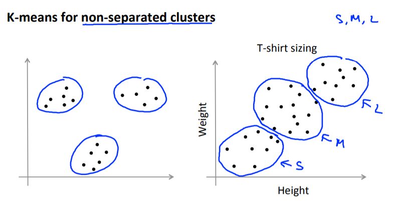

K means algorithm의 다른 일반적인 적용(잘 분리되지 않은 클러스터)에 대해 살펴보자.

잘 분리된 클러스터가 없을 수 있는 데이터 집합에서 K means를 적용하는 경우는 흔히 일어난다. T-shirt size의 예시를 살펴보자.

내가 작은 사이즈, 중간 사이즈, 큰 사이즈의 티셔츠를 디자인하고 판매하고 싶다고 하자. 그러면 내 작은 것을 얼마나 크게 만들어야 할까? 미디엄 사이즈는 얼마나 커야 할까? 그리고 내 큰 티셔츠를 얼마나 크게 만들어야 할까.

K means algorithm을 실행하여 각각 cluster로 그룹화하고, 각 그룹에서의 집단을 보고 각 집단에 잘 맞도록 디자인하는 것이 좋겠다.

## Optimization objective

K-means 또한 우리가 최소화를 해야할 optimization objective 또는 cost function을 가진다.

1. 디버그하는데 도움을 준다.
2. local optima를 피하고 더나은 cost를 찾는데 도움을 준다.

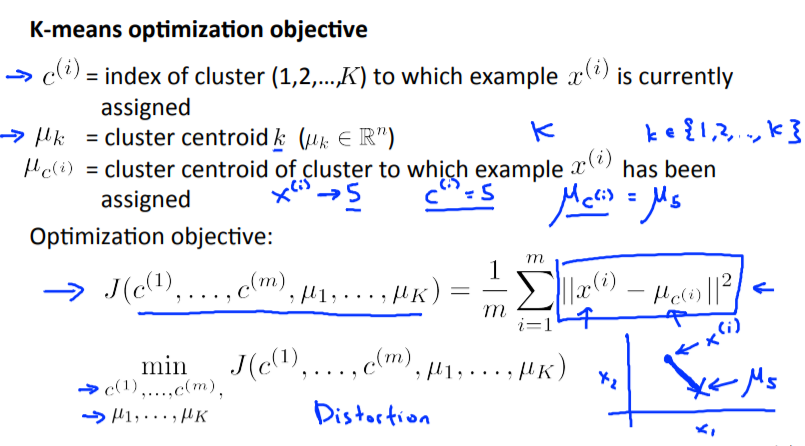

- $c^{(i)}$ : $x^{(i)}$가 현재 할당된 클러스터의 인덱스
- $\mu_K$ : 클러스터 k의 중심
- $\mu_{c^{(i)}}$ : $x^{(i)}$가 할당된 클러스터의 중심

이 비용함수 J를 최소화하기 위해 C와 mu를 찾는데, 이 비용함수를 떄때로 distortion이라고 부르기도 한다.

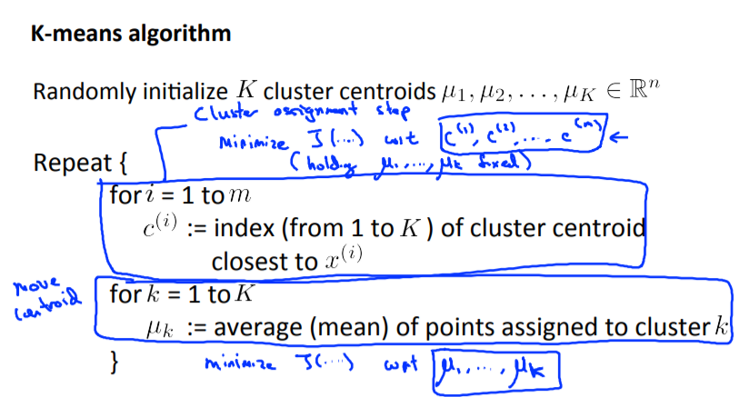

## Random initialization

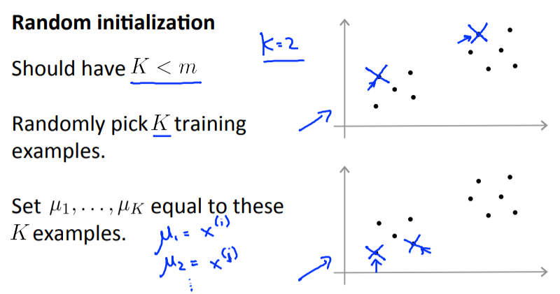

1. K개의 cluster centroids를 랜덤하게 초기화한다.

2.관측치 갯수만큼 가까운 것들을 각각cluster centroid로 배정한다.  
3.K개의 cluster centroid각각을 각 그룹 내의 평균점으로 할당한다.

K가 M보다 작도록 설정되어야 한다. K-means를 관측치보다 같거나 더 많은 수의 K로 실행한다면 이상할 것이다.

K가 2인 경우를 생각하고 두개의 클러스터를 찾아보자.  
cluster centroids를 초기화하기 위해 무작위로 2개의 examples를 선택했다.

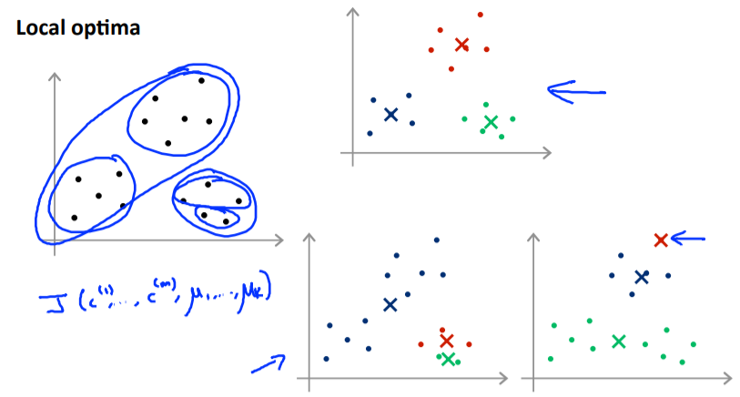

랜덤하게 선택되는 cluster centroids에 따라서 cluster들의 수렴 결과가 달라진다.  
K-means는 결국 다른 solution을 가질 수 있는데, 특히 실제로 local optima로 끝날 수 있다.

가능한 최상의 cluster을 찾을 확률을 높이려면, 다중 무작위 초기화를 시도하는 것이다.  
그래서, K-means를 한 번 초기화하는 대신, 여러 번 초기화하고 여러 번 실행하는 것이다.

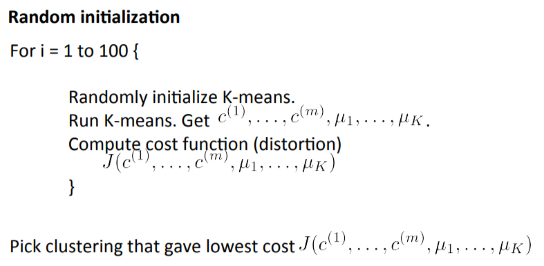

이 과정을 100번 반복한 뒤, 데이터를 clustering한 수백 가지 방법 중 하나를 선택하면 된다. 이 방법은 가장 낮은 cost를 가지고 있다.  
k갯수가 2~10개 정도이면, 랜덤 초기화를 여러번 수행하면 더 나은 로컬 최적화를 찾을 수도 있지만, k가 10보다 훨씬크면, 다중 랜덤 초기화를 사용하는 것이 큰 차이를 만들 가능성이 적다.

## Choosing the number of clusters

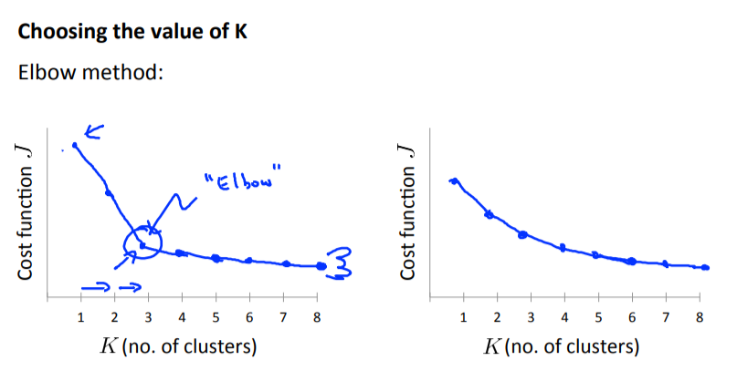

k를 자동으로 선택하는 방법은 별로 없고, 시각화를 보거나 output을 통해 보는 수동으로 선택한다.

그러면 어떻게 cluster 갯수를 선택할 것인가?

k에 따른 cost의 그래프에서 elbow의 지점에 해당하는 k를 선택하면 된다.  
왼쪽그림에서는 k=3을 선택하게 된다.

elbow method를 이용하면 모호하고 깔끔하지 않다는 단점도 있다.  
또, 오른쪽 그림같은 경우 elbow의 위치가 분명하지 않다. 그래서 클러스터의 갯수를 선택하기 어렵다.

elbow method에 대해 요약하자면, 그려볼 가치는 있지만 꼭 필요하지는 않다.

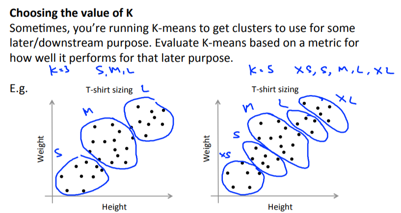

k를 3으로 선택할 때와 5로 선택할 때는 위와 같다.  
이것은 단지 티셔츠 사업의 관점에서 생각해보고 클러스터의 갯수를 생각해보는 것이다.

## Practice

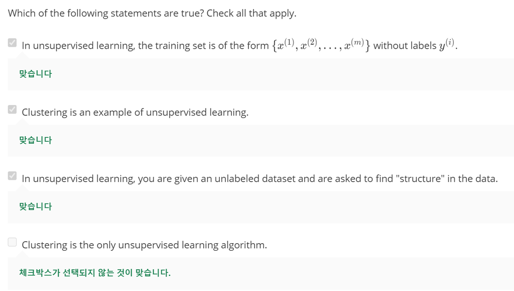

클러스터링은 둘 다 이용될 수 있다.

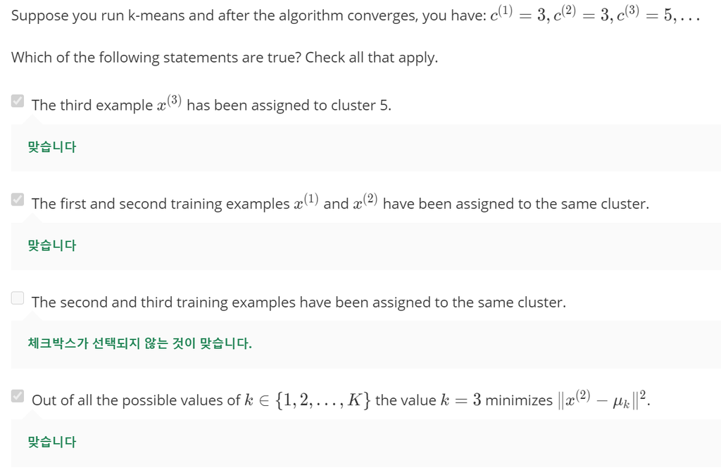

두번째는 3의 클러스터,세번째는 5의 클러스터로 할당된다.

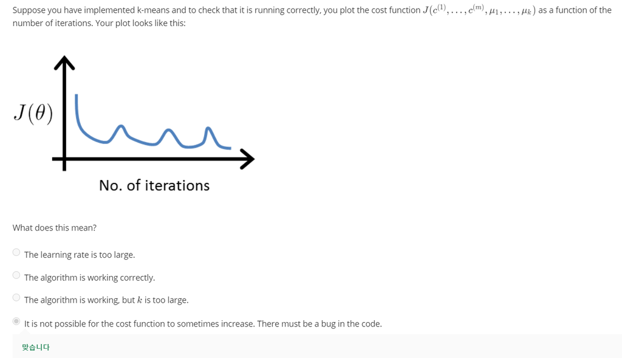

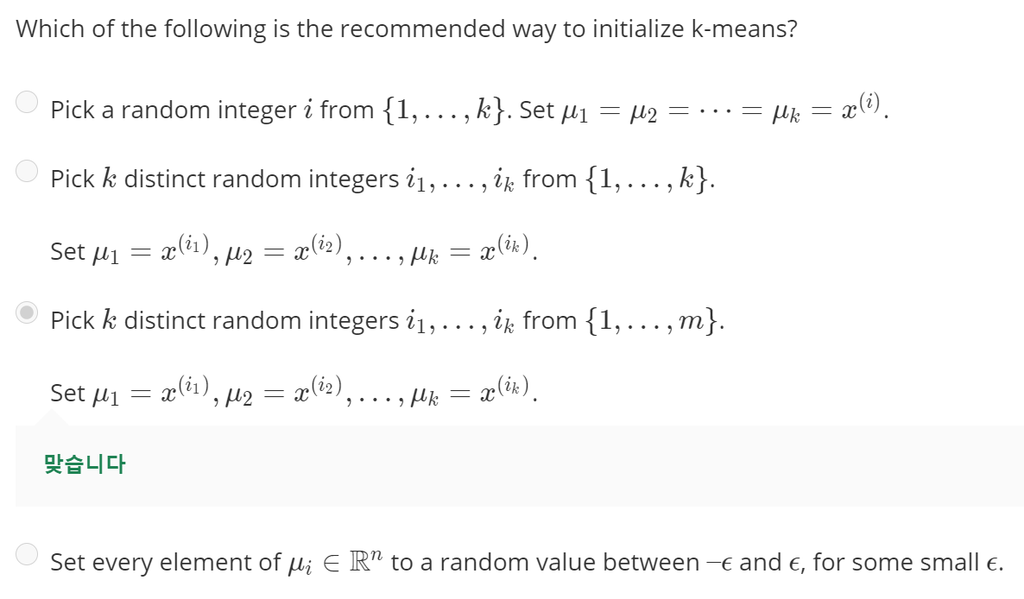

데이터 포인트 중 랜덤으로 선택

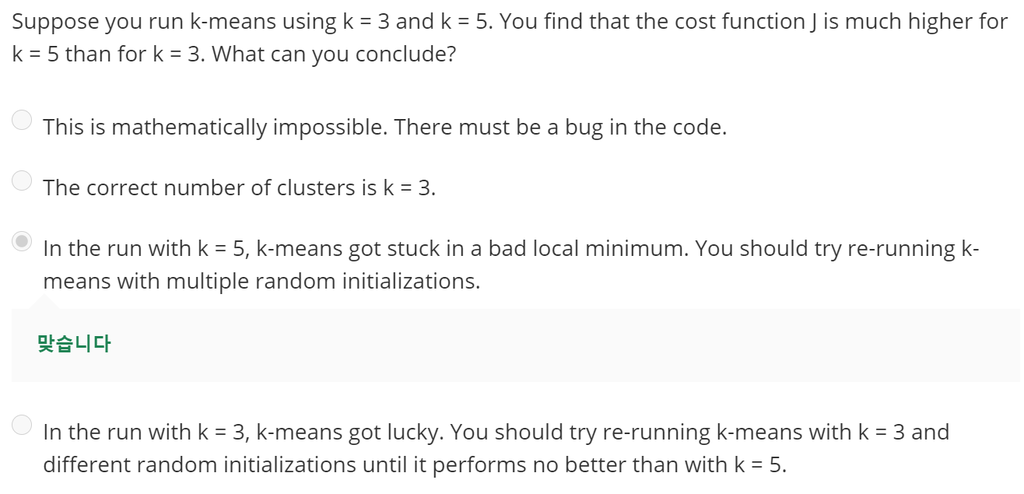

k를 늘려감에 따라 cost가 같거나 감소해야하는데, 잘못된 오류가 발생했다고 생각할 수 있을것

## Exercise

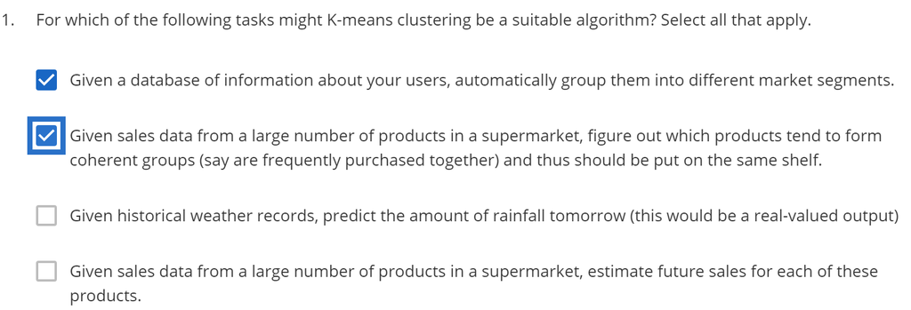

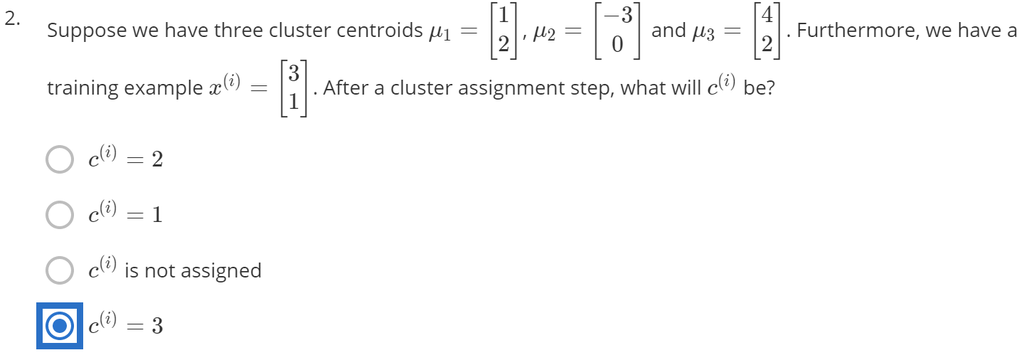

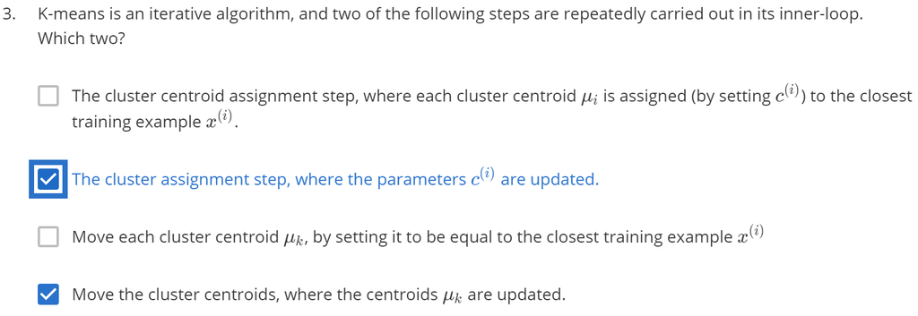

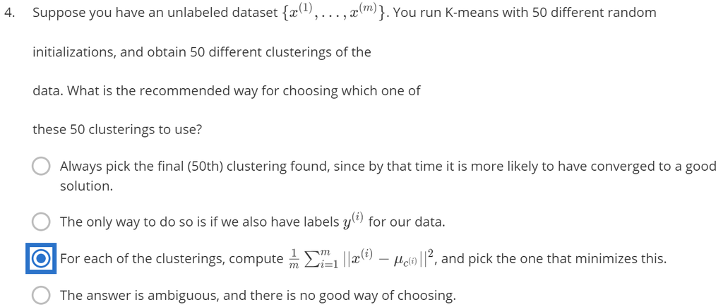

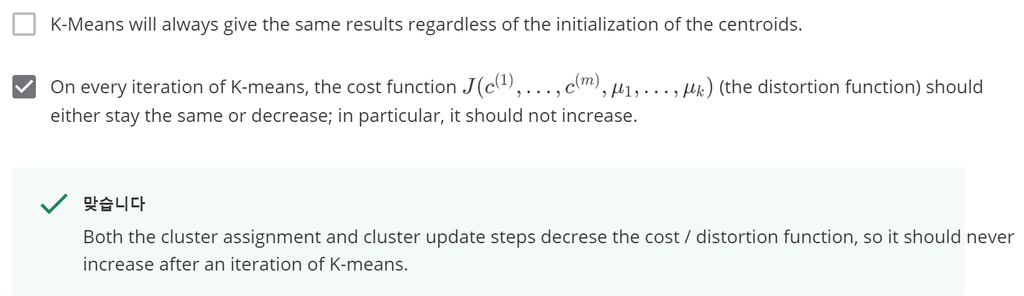

## Refer

[Image Resize](https://www.birme.net/?target_width=600&target_height=450)  
[Image gif in r(magick)](https://stackoverflow.com/questions/53683709/create-gif-or-video-from-external-jpg-in-r)